# DissociationTest.Rmd

Rayna M Harris

November 20, 2017

## Methods for Dorsal Hippocampal Gene Expression Profiling

#### Part 1: Examining the influence of dissasociation on gene expression in the CA1, CA3, and DG

This PCA gives an overview of the variability between samples using the a large matrix of log transformed gene expression data. You can see that the bigges difference is between DG punches and the CA1 and CA3 punches. CA1 and CA3 samples have similar transcriptomes. The homogenized CA1 samples have the most similar transcriptonal profiles as evidenced by their tight clustering.

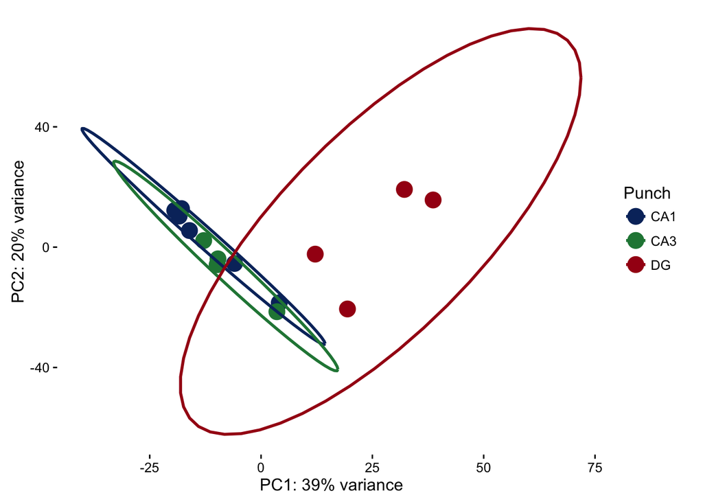

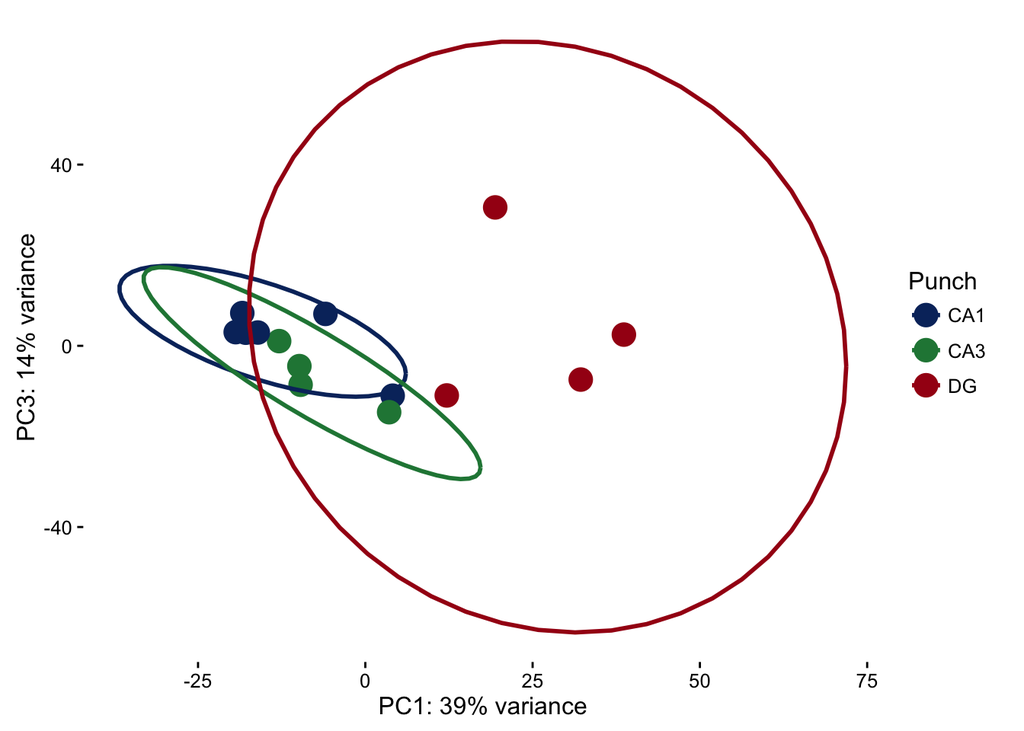

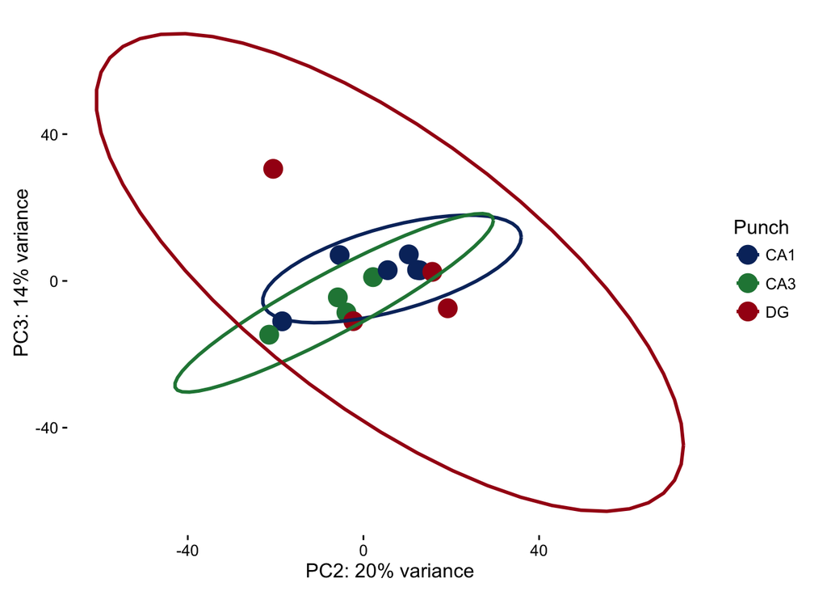

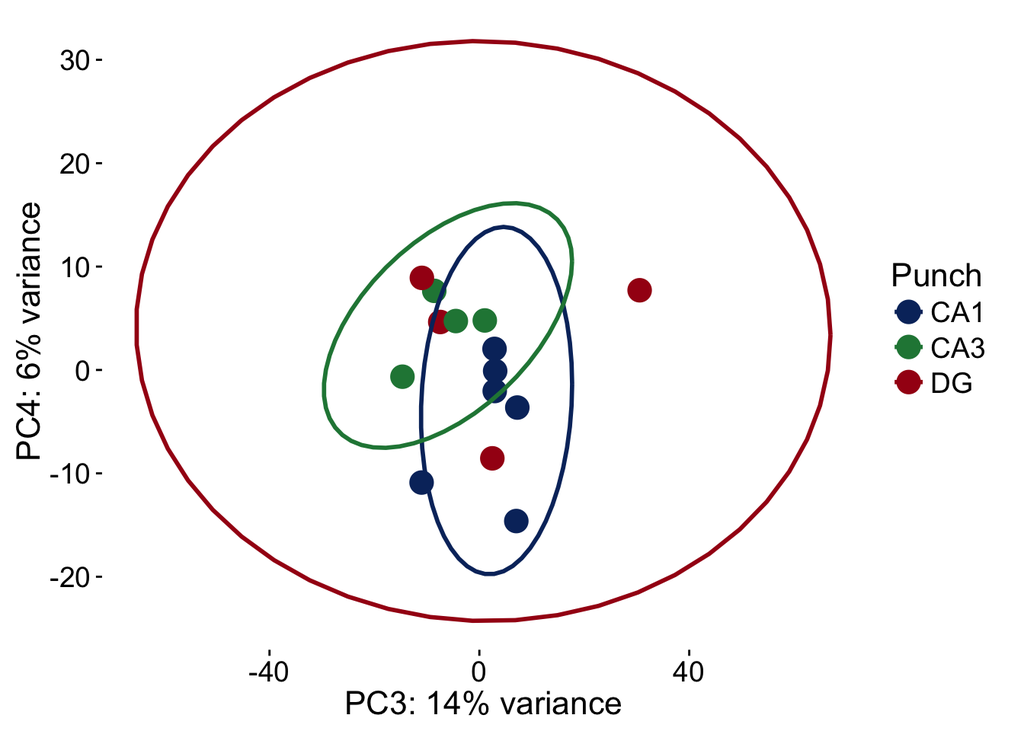

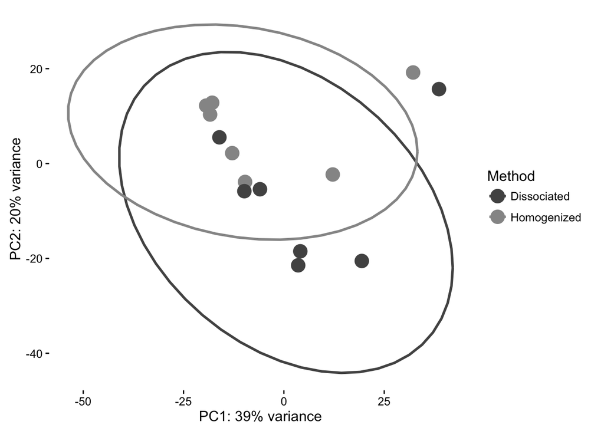

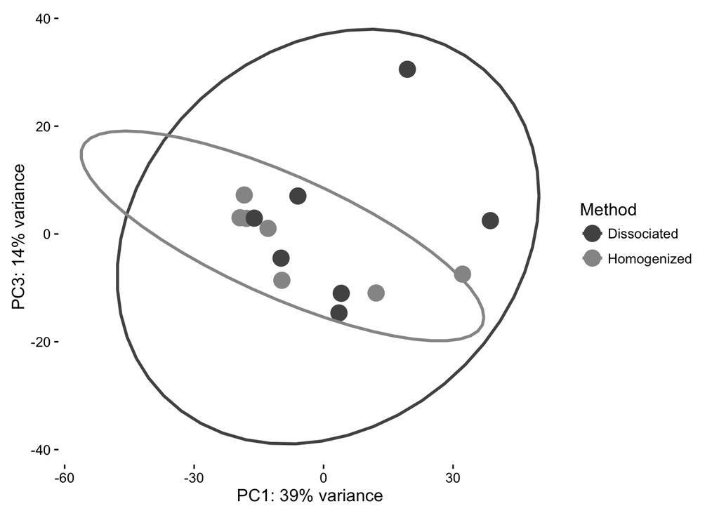

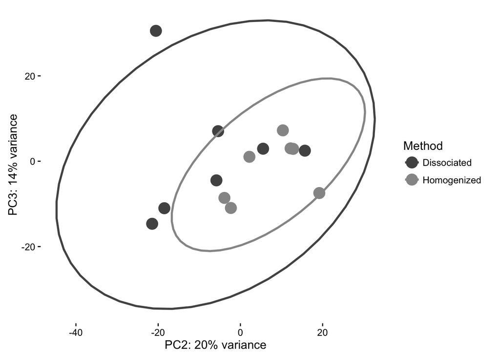

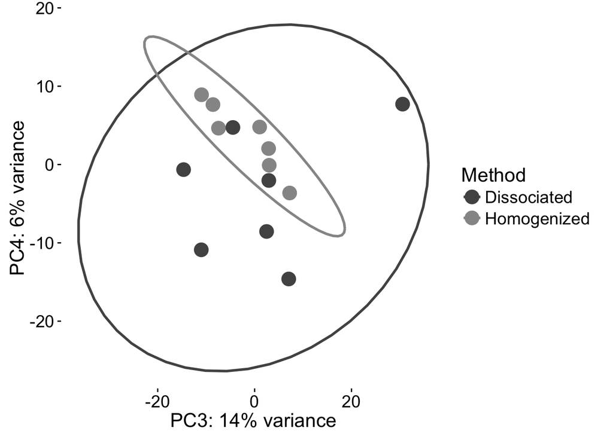

This Venn Diagram shows the number of differentially expressed by contrast described above each oval. The most number of genes are differntially expressed between DG and the CAs (nearly 1000) wheras only about 200 were differntailly regulated as a result of of technical maniplulation comparing homogenized and dissociated samples.

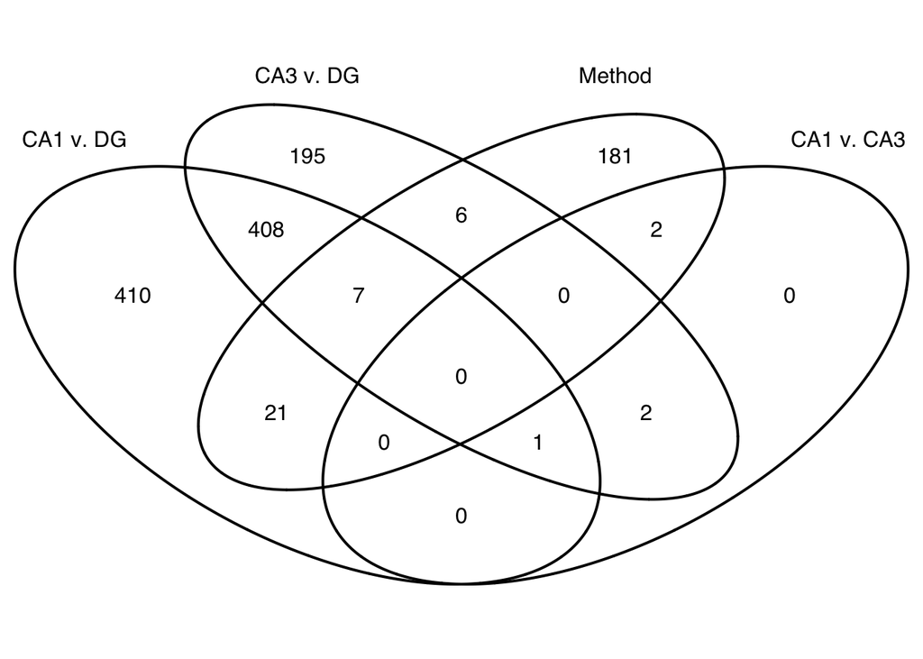

Here, the goal is the analyze the distribution of pvalues to see if they are randomly distributed or if that is a tendency towards and increase or decrease of low pvalues. There, I’m showing the pval and adjusted pvale (padj) for all for two-way comparision.

```r
head(rldpvals)
```

```
##               pvalPunchCA1DG padjPunchCA1DG pvalPunchCA3DG padjPunchCA3DG
## 0610007P14Rik     0.46932500      0.9208541    0.696908058      0.9352295
## 0610009B22Rik     0.84263306      1.0000000    0.728972247      0.9510461
## 0610009L18Rik     0.02235745      0.2096133    0.062007917      0.3987984
## 0610009O20Rik     0.95464346      1.0000000    0.822217823      0.9875427
## 0610010F05Rik     0.34360675      0.8017734    0.338898359      0.8119113
## 0610010K14Rik     0.40276188      0.8610756    0.004220377      0.1076258
##               pvalPunchCA1CA3 padjPunchCA1CA3
## 0610007P14Rik      0.20093815               1
## 0610009B22Rik      0.85177917               1
## 0610009L18Rik      0.63946182               1
## 0610009O20Rik      0.73029388               1
## 0610010F05Rik      0.98085888               1
## 0610010K14Rik      0.01860027               1
##               pvalMethodHomogenizedDissociated
## 0610007P14Rik                        0.3871011
## 0610009B22Rik                        0.7589831
## 0610009L18Rik                        0.7636202
## 0610009O20Rik                        0.6086783
## 0610010F05Rik                        0.5736701
## 0610010K14Rik                        0.7620727
##               padjMethodHomogenizedDissociated
## 0610007P14Rik                        0.9540705
## 0610009B22Rik                        0.9997501
## 0610009L18Rik                        0.9997501
## 0610009O20Rik                        0.9986449
## 0610010F05Rik                        0.9909888
## 0610010K14Rik                        0.9997501
```

```r
rldpvalslong <- rldpvals
rldpvalslong$gene <- row.names(rldpvalslong)
rldpvalslong <- melt(rldpvalslong, id=c("gene"))
head(rldpvalslong)
```

```
##            gene       variable      value
## 1 0610007P14Rik pvalPunchCA1DG 0.46932500
## 2 0610009B22Rik pvalPunchCA1DG 0.84263306
## 3 0610009L18Rik pvalPunchCA1DG 0.02235745
## 4 0610009O20Rik pvalPunchCA1DG 0.95464346
## 5 0610010F05Rik pvalPunchCA1DG 0.34360675
## 6 0610010K14Rik pvalPunchCA1DG 0.40276188
```

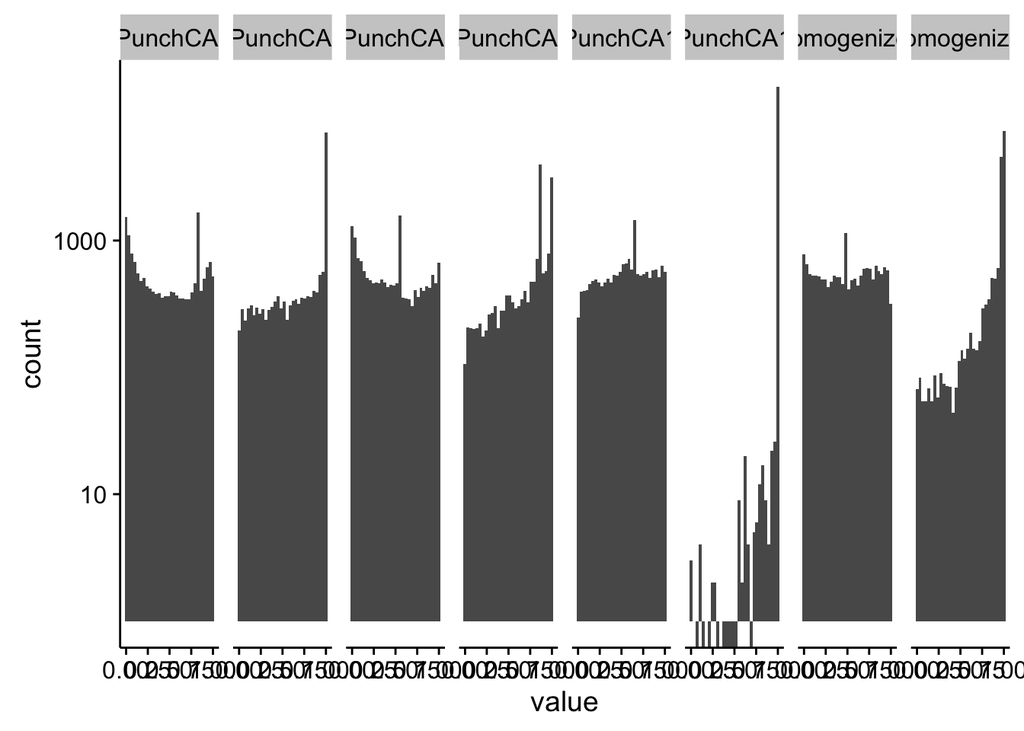

```r
qplot(value, data=rldpvalslong, geom="histogram") +
  facet_grid( ~ variable) +
  scale_y_log10()
```

Here, you can see that the differences between samples is not as clear cut for all comparisions. What other mechanisms would be useful for subseting the data to identify genes of interest?

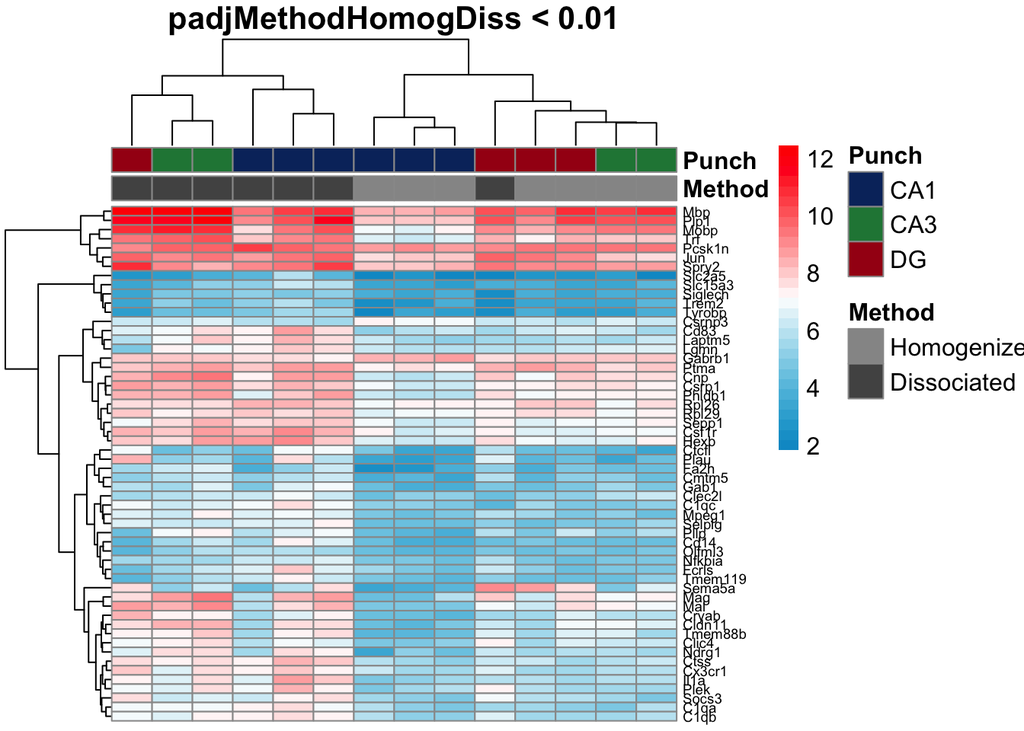

This is a data validation check plot. Here, I’m showing how many millions of reads were present in each sample. On average, each sample had 5 million reads, but the range was from 0.8 to 10 millino reads.

```
FALSE [1] 22485    14
```

```
FALSE 100-CA1-1 100-CA1-2 100-CA1-3 100-CA3-1 100-CA3-4  100-DG-2  100-DG-3
FALSE  2.310696  6.646222  2.276635  1.974208  2.351650  1.285004  6.086292
FALSE 101-CA1-1 101-CA1-2 101-CA1-3 101-CA3-1 101-CA3-4  101-DG-3  101-DG-4
FALSE  4.782463  0.133622  0.300000  2.498531  1.192730  0.063507  0.598340
```

```
FALSE
FALSE    0    2    3    4    5    6    7    8    9   10   11   12   13   14   15
FALSE 5566  363  242  174  191  155  127  131  127  114  104  104   82   72   86
FALSE   16   17   18   19   20   21   22   23   24   25   26   27   28   29   30
FALSE   67   76   72   53   68   45   56   63   54   54   56   54   57   55   39
```

```
FALSE 'data.frame': 14 obs. of  2 variables:
FALSE  $ V1: int  151 151 151 151 151 151 151 151 151 151 ...
FALSE  $ V2: num  5220597 9496400 6060222 6780934 3658178 ...
```

```
FALSE [1] 4918879
```

```
FALSE [1] 68864306
```

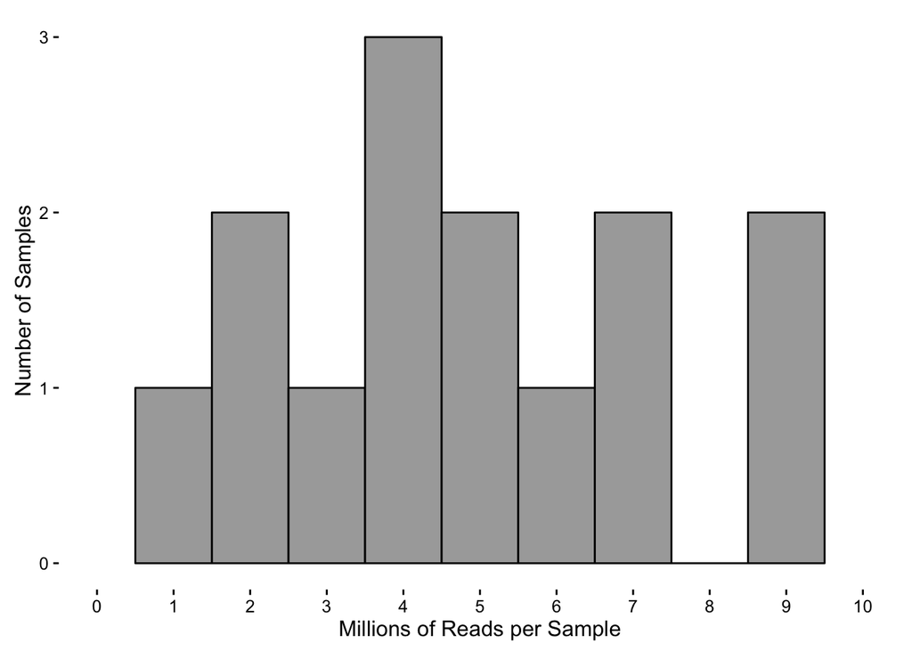

These next graphs show the correlation between samples of CA1, CA3, and DG.

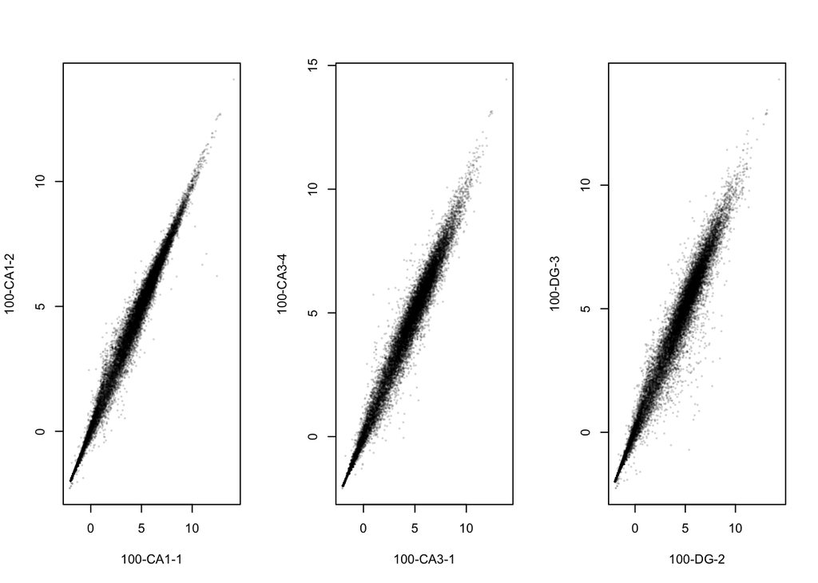

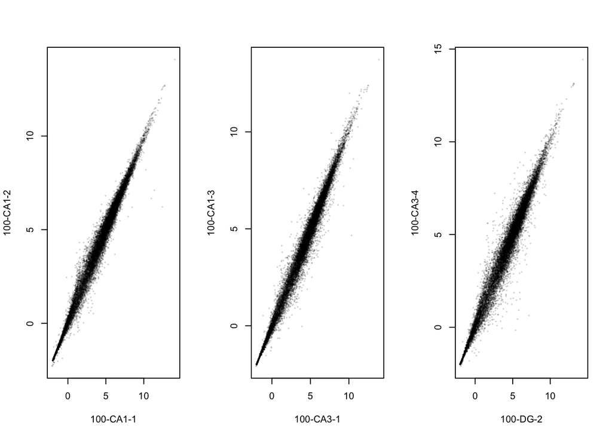

This next plot shows the stregnth of the correlation between samples.

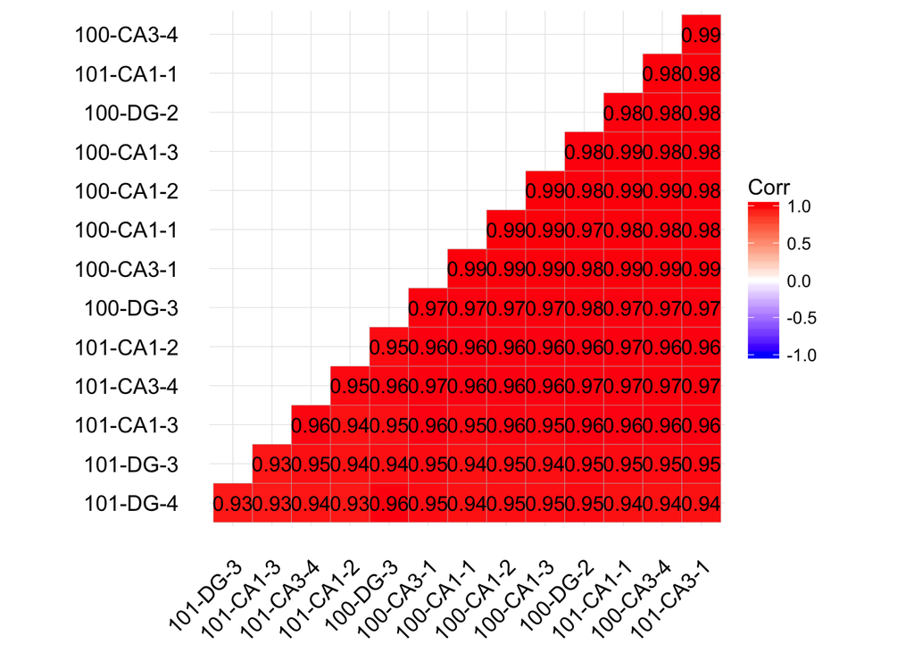